# Midpoint Deliverable

## Crime And Location In The City Of Chicago

### Introduction

Eventhough crime data may kept confidential due to people’s privacy, we are interested to make the best use of open datasets to promote awareness of personal safety and of possible research purposes. In this case, we want to explore the relationship between crime type and location referring to the Chicago Crime dataset of incidents occurred in the city since 2001 to as recent as 7 days ago, gathered and publicized by *[Chicago Police Department](https://data.cityofchicago.org/Public-Safety/Crimes-2001-to-present/ijzp-q8t2)*

### Summary Paragraph

The dataset we used consists with quiet large and specific data such as estimate date and time, whether or not criminals were arrested, whether these incidents are domestic violence, even the exact latitude and longitude of location. Our choosen set include every incidents from 2009 to 2019. We chose the year of 2019 as a sample size to calculate the the summary information. They are the the total number of incidents occured, the arrest rate relative to that, the most frequently occured crime, and its percentage relative to the total number of crime and the location that has the highest crime rate. In the year of 2019, the City of Chicago had 664779 crimes occured, and the arrest rate is 20.03%, among all the most frequently occured crime is **THEFT**, it counts for 23.99% of the total amount of crime. In addition, **STREET** as a typical location description has the highest crime rate among all 146 locations recorded.( Noted that all numbers involved calculation of percentage are rounded to two decimals.)

### Summary Table

This table shows the aggregate number of crime occurred in different recorded typical locations and the percentage of proportion relative to the total number of crime in the City of Chicago in the year of 2019. This table is an extraction of the top 20 of such statistic and is arranged by decreasing number of crime rate. This information is displayed to show that more crime occurred in residential and semi-public areas than public areas. ( Noted that all numbers involved calculation of percentage are rounded to two decimals.)

| Location Description Recorded | Number Of Crime Occurred | Percent of The Number of TotalCrime |
| --- | --- | --- |
| STREET | 147398 | 22.17 |
| RESIDENCE | 111756 | 16.81 |
| APARTMENT | 85775 | 12.90 |
| SIDEWALK | 51780 | 7.79 |
| OTHER | 27358 | 4.12 |
| PARKING LOT/GARAGE(NON.RESID.) | 19771 | 2.97 |
| RESTAURANT | 17972 | 2.70 |
| SMALL RETAIL STORE | 17544 | 2.64 |
| ALLEY | 12736 | 1.92 |
| RESIDENTIAL YARD (FRONT/BACK) | 12663 | 1.90 |
| VEHICLE NON-COMMERCIAL | 12151 | 1.83 |
| RESIDENCE PORCH/HALLWAY | 11619 | 1.75 |
| DEPARTMENT STORE | 11582 | 1.74 |
| RESIDENCE-GARAGE | 10016 | 1.51 |
| GAS STATION | 9470 | 1.42 |
| SCHOOL, PUBLIC, BUILDING | 8884 | 1.34 |
| GROCERY FOOD STORE | 8714 | 1.31 |
| BAR OR TAVERN | 5378 | 0.81 |
| CTA TRAIN | 5054 | 0.76 |
| CONVENIENCE STORE | 5020 | 0.76 |

### Charts

[figure not shown]

The bar chart displays the top ten most committed types of crime in Chicago from 2009 to now. Each bar represents the total frequency that each crime type occurs in the 10-year period. It is clear that the frequency of theft and battery are significantly higher than the rest.

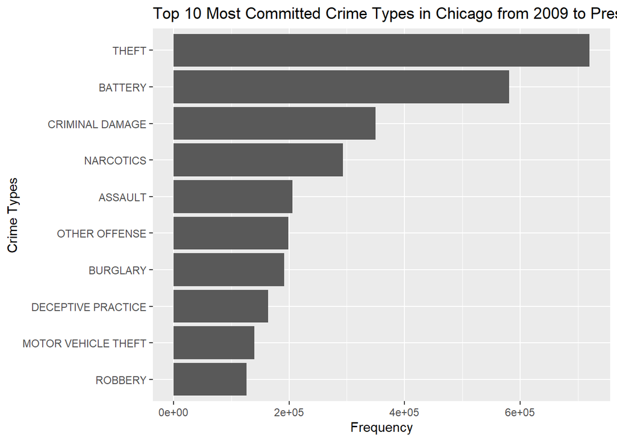